# Preprocessing Univ

2025-10-01

# 1 Detección de outliers univariante: variables numéricas

Variables a estudiar:

```r
varNum<-c("Age", "CreditScore", "Tenure","EstimatedSalary", "Balance", "NumOfProducts",
          "TransactionFrequency","AvgTransactionAmount","DigitalEngagementScore",
          "ComplaintsCount","NetPromoterScore")
```

## 1.1 Simetría de las variables

Primero ejecutamos un test de simetría para saber qué método usar para la detección de outliers en cada variable.

```r
p<-sapply(varNum, function(v) symmetry.test(data[[v]])$p.value)
symmetry_test <- data.frame(
  p.value = p,
  significative=(p<0.05)
)
symmetry_test <- symmetry_test[order(symmetry_test$p.value), ]
print(symmetry_test)
```

```
##                        p.value significative
## Age                      0.000          TRUE
## Balance                  0.000          TRUE
## NumOfProducts            0.000          TRUE
## AvgTransactionAmount     0.000          TRUE
## ComplaintsCount          0.000          TRUE
## NetPromoterScore         0.000          TRUE
## DigitalEngagementScore   0.002          TRUE
## CreditScore              0.152         FALSE
## TransactionFrequency     0.236         FALSE
## EstimatedSalary          0.854         FALSE
## Tenure                   0.856         FALSE
```

Parece que únicamente CreditScore, TransactionFrequency, Tenure y EstimatedSalary han soportado el test y pueden ser consideradas simétricas. No obstante, el p-valor de CreditScore y quizás el de TransactionFrequency merecen una inspección más a fondo.

Todas las variables con p-valor inferior a 0.05 rechazan claramente simetría.

Ahora, para reafirmar o terminar de definir las conclusiones de este test, realizaremos una inspección visual de las distribuciones para evaluar su simetría:

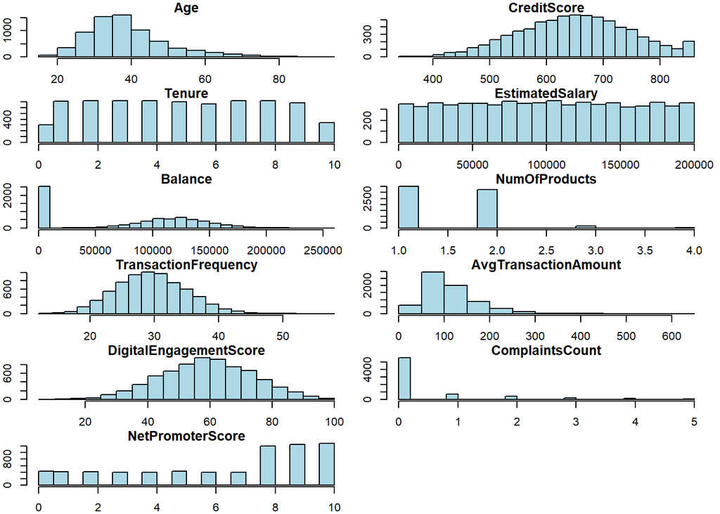

```r
n_vars <- length(varNum)
ncol <- 2
nrow <- ceiling(n_vars / ncol)

par(mfrow = c(nrow, ncol), mar = c(2, 2, 1, 1))

for (var in varNum) {
  hist(data[[var]],
       main = paste(var),
       xlab = var,
       col = "lightblue",
       breaks = 20)
}
```

NumOfProducts y ComplaintsCount son conteos (variables discretas), por lo que no tiene mucho sentido aplicar métodos basados en cálculos numéricos

Pese a que TransactionFrequency, Tenure y EstimatedSalary pueden ser validadas como simétricas, CreditScore es algo confusa. Realizaremos un último test:

```r
skewness(data$CreditScore, na.rm = TRUE)
```

```
## [1] -0.06489675
```

El valor, muy cercano a 0, de la prueba de Fisher nos permite confirmar CreditScore como variable simétrica.

```r
sum(data$Balance == 0, na.rm = TRUE)
```

```
## [1] 2545
```

Dado que son valores posibles (clientes con la cuenta en 0) y a nivel del contexto del estudio es algo que podemos entender como normal, no clasificaremos dichos valores como outliers pese a estar alejados de la población que no tiene Balance=0 en la cuenta.

Ahora procedemos a dividir nuestras variables numéricas en simétricas y no simétricas para continuar con el análisis adecuado en cada caso:

```r
symmetric<-c("TransactionFrequency", "Tenure", "EstimatedSalary", "CreditScore")
non_symmetric<-c("Age","AvgTransactionAmount","DigitalEngagementScore", "NetPromoterScore")
varNum
```

```
##  [1] "Age"                    "CreditScore"            "Tenure"
##  [4] "EstimatedSalary"        "Balance"                "NumOfProducts"
##  [7] "TransactionFrequency"   "AvgTransactionAmount"   "DigitalEngagementScore"
## [10] "ComplaintsCount"        "NetPromoterScore"
```

## 1.2 Outliers variables simétricas

Procedemos a la detección de outliers para las variables simétricas. Para ello utilizaremos el rango intercuartílico (IQR), de modo que los valores que queden fuera de dicho intervalo serán reconocidos como outliers univariantes

```r
outlier_positions <- list()
IQROutlier <- function(variable, rmnas = TRUE) {
  IQ <- IQR(variable, na.rm = rmnas)
  intInf <- quantile(variable, probs = c(0.25, 0.75),na.rm = rmnas)[[1]] - 1.5*IQ
  intSup <- quantile(variable, probs = c(0.25, 0.75),na.rm = rmnas)[[2]] + 1.5*IQ
  posicions <- which(variable >= intSup | variable <= intInf)
  if (length(posicions) > 0) {
    cat("Existen outliers en las posiciones:", paste0(posicions, collapse = ", "))
  } else {
    cat("No existen outliers")
  }
  return(posicions)
}
for (var in symmetric) {
  cat("\nVariable:", var, "\n")
  pos <- IQROutlier(data[[var]])
  if (length(pos) > 0) {
    outlier_positions[[var]] <- pos
  }
}
```

```
##
## Variable: TransactionFrequency
## Existen outliers en las posiciones: 145, 236, 494, 921, 1581, 2110, 2117, 2181, 2273, 2617, 2940, 3104, 3148, 3206, 3791, 4887, 4943, 5303, 5698, 5819, 5987, 6209, 7282, 7320, 7592, 7960, 8000, 8416, 9118, 9776, 9784, 9953
## Variable: Tenure
## No existen outliers
## Variable: EstimatedSalary
## No existen outliers
## Variable: CreditScore
## Existen outliers en las posiciones: 728, 1256, 1412, 1525, 3182, 3223, 4300, 4580, 7486, 9986
```

```r
outlier_positions
```

```
## $TransactionFrequency
##  [1]  145  236  494  921 1581 2110 2117 2181 2273 2617 2940 3104 3148 3206 3791
## [16] 4887 4943 5303 5698 5819 5987 6209 7282 7320 7592 7960 8000 8416 9118 9776
## [31] 9784 9953
##
## $CreditScore
##  [1]  728 1256 1412 1525 3182 3223 4300 4580 7486 9986
```

```r
longitudes_s <- sapply(outlier_positions, length)
longitudes_s
```

```
## TransactionFrequency          CreditScore
##                   32                   10
```

Las variables EstimatedSalary y Tenure no tienen outliers.

TransactionFrequency y CreditScore tienen una proporcion muy baja de outliers, pero puede tener sentido dado que son distribuciones muy compactas:

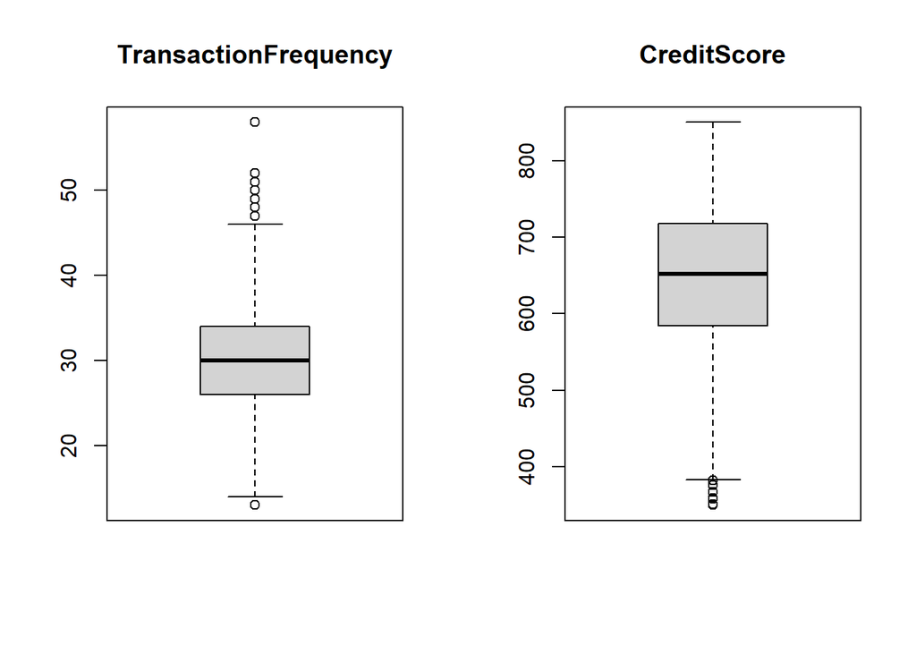

```r
par(mfrow = c(1, 2))
boxplot(data$TransactionFrequency, main = "TransactionFrequency")
boxplot(data$CreditScore, main = "CreditScore")
```

## 1.3 Outliers variables no simétricas

Ahora, para las variables no simétricas, utilizaremos el método del Hampel Identifier. Este método usa la mediana y MAD (Median Absolute Deviation) por ser estadísticos robustos que no se ven afectados por la asimetría de los datos. A diferencia de la media y desviación estándar, no asumen distribución normal y son resistentes a valores extremos. Esto permite detectar outliers reales sin que la forma sesgada de la distribución afecte los límites de detección.

```r
hampelOutlier <- function(variable, mad_constant = 1, threshold = 3.5) {
  med <- median(variable, na.rm = TRUE)
  mad_val <- mad(variable, constant = mad_constant, na.rm = TRUE)

  lower_bound <- med - threshold * mad_val
  upper_bound <- med + threshold * mad_val

  which((variable < lower_bound) | (variable > upper_bound))
}

outlier_positions_non_symmetric <- list()

for (var in non_symmetric) {
  outliers <- hampelOutlier(data[[var]])
  if (length(outliers) > 0) {
    outlier_positions_non_symmetric[[var]] <- outliers
  }
}

outlier_positions_non_symmetric
```

```
## $Age
##   [1]   39   41  109  149  182  205  272  275  297  338  384  406  407  430  461
##  [16]  463  472  504  509  511  530  552  557  582  618  657  671  694  758  760
##  [31]  786  807  835  849  875  880  890  896  928  961  990 1016 1029 1073 1099
##  [46] 1125 1141 1217 1221 1230 1260 1267 1274 1275 1298 1302 1310 1316 1363 1371
##  [61] 1386 1394 1422 1432 1442 1452 1483 1548 1553 1569 1606 1612 1620 1627 1646
##  [76] 1705 1711 1786 1803 1816 1831 1859 1875 1878 1907 1926 1955 1969 1976 1988
##  [91] 1990 2004 2007 2011 2026 2030 2032 2036 2103 2112 2145 2156 2173 2187 2192
## [106] 2242 2284 2320 2330 2342 2405 2421 2442 2447 2484 2499 2526 2566 2573 2647
## [121] 2674 2688 2695 2704 2708 2712 2726 2729 2745 2767 2786 2792 2809 2850 2878
## [136] 2889 2931 2970 3007 3030 3066 3075 3084 3097 3104 3120 3122 3132 3135 3159
## [151] 3226 3275 3292 3302 3308 3315 3368 3399 3450 3483 3493 3547 3551 3579 3636
## [166] 3655 3667 3675 3707 3710 3764 3785 3800 3839 3861 3865 3893 3926 3936 3954
## [181] 3961 4008 4030 4095 4115 4144 4160 4217 4319 4356 4387 4430 4506 4511 4534
## [196] 4557 4592 4618 4619 4640 4650 4655 4666 4704 4709 4712 4742 4750 4760 4768
```

[output cut: 87 more lines]

```r
longitudes_ns <- sapply(outlier_positions_non_symmetric, length)
longitudes_ns
```

```
##                    Age   AvgTransactionAmount DigitalEngagementScore
##                    424                    464                     81
##       NetPromoterScore
##                    423
```

Ahora haremos una comparación de las proporciones segun el grupo (train o test) para evaluar si hay alguna anomalía.

```r
prop_test <- 30
prop_train <- 70
todas_outliers<-c(outlier_positions, outlier_positions_non_symmetric)
proporcion_outliers_completa <- data.frame(
  Variable = character(),
  Grupo = character(),
  N_Outliers = integer(),
  Total_Outliers = integer(),
  Proporcion_Outliers = numeric(),
  Proporcion_Esperada = numeric(),
  Diferencia = numeric(),
  stringsAsFactors = FALSE
)

for (var in names(todas_outliers)) {
  outliers <- todas_outliers[[var]]
  total_outliers_var <- length(outliers)

  if (total_outliers_var > 0) {
    outliers_test <- sum(data$group[outliers] == "test")
    outliers_train <- sum(data$group[outliers] == "train")

    proporcion_outliers_completa <- rbind(proporcion_outliers_completa,
      data.frame(
        Variable = var,
        Grupo = "test",
        N_Outliers = outliers_test,
        Total_Outliers = total_outliers_var,
        Proporcion_Outliers = round(outliers_test / total_outliers_var * 100, 1),
        Proporcion_Esperada = round(prop_test, 1),
        Diferencia = round((outliers_test / total_outliers_var * 100) - prop_test, 1)
      ),
      data.frame(
        Variable = var,
        Grupo = "train",
        N_Outliers = outliers_train,
        Total_Outliers = total_outliers_var,
        Proporcion_Outliers = round(outliers_train / total_outliers_var * 100, 1),
        Proporcion_Esperada = round(prop_train, 1),
        Diferencia = round((outliers_train / total_outliers_var * 100) - prop_train, 1)
      )
    )
  }
}

# Mostrar resultados
proporcion_outliers_completa
```

```
##                  Variable Grupo N_Outliers Total_Outliers Proporcion_Outliers
## 1    TransactionFrequency  test         10             32                31.2
## 2    TransactionFrequency train         22             32                68.8
## 3             CreditScore  test          2             10                20.0
## 4             CreditScore train          8             10                80.0
## 5                     Age  test        122            424                28.8
## 6                     Age train        302            424                71.2
## 7    AvgTransactionAmount  test        152            464                32.8
## 8    AvgTransactionAmount train        312            464                67.2
## 9  DigitalEngagementScore  test         24             81                29.6
## 10 DigitalEngagementScore train         57             81                70.4
## 11       NetPromoterScore  test        138            423                32.6
## 12       NetPromoterScore train        285            423                67.4
##    Proporcion_Esperada Diferencia
## 1                   30        1.2
## 2                   70       -1.2
## 3                   30      -10.0
## 4                   70       10.0
## 5                   30       -1.2
## 6                   70        1.2
## 7                   30        2.8
## 8                   70       -2.8
## 9                   30       -0.4
## 10                  70        0.4
## 11                  30        2.6
## 12                  70       -2.6
```

Vemos que las proporciones tienen bastante sentido si las miramos segun el grupo train/test.

## 1.5 Detección de valores imposibles

Ahora haremos un summary de las variables donde hemos detectado outliers para determinar si hay valores imposibles (como una persona con edad 180).

```r
variables_con_outliers <- names(todas_outliers)
summary(data[variables_con_outliers])
```

```
##  TransactionFrequency  CreditScore         Age        AvgTransactionAmount
##  Min.   :13.00        Min.   :350.0   Min.   :18.00   Min.   : 19.60
##  1st Qu.:26.00        1st Qu.:584.0   1st Qu.:32.00   1st Qu.: 70.12
##  Median :30.00        Median :652.0   Median :37.00   Median : 98.61
##  Mean   :30.06        Mean   :650.7   Mean   :39.01   Mean   :111.76
##  3rd Qu.:34.00        3rd Qu.:718.0   3rd Qu.:44.00   3rd Qu.:138.02
##  Max.   :58.00        Max.   :850.0   Max.   :92.00   Max.   :611.35
##  NA's   :3000         NA's   :3000    NA's   :3000    NA's   :3000
##  DigitalEngagementScore NetPromoterScore
##  Min.   :  5.00         Min.   : 0.00
##  1st Qu.: 50.00         1st Qu.: 4.00
##  Median : 60.00         Median : 8.00
##  Mean   : 59.55         Mean   : 6.44
##  3rd Qu.: 70.00         3rd Qu.: 9.00
##  Max.   :100.00         Max.   :10.00
##  NA's   :3000           NA's   :3000
```

A partir de estos datos y del entendimiento de la naturaleza de las variables expuestas:

Rechazamos que haya valores imposibles: aceptamos los outliers como producto de la aleatoriedad natural.